# Figure 1. A Hypothetical Example of 1,000 Workers and Seven Occupations

This figure provides a hypothetical example of how we constructed occupational network.The script does not require a data set. It has four components: a 7X7 transition matrix (Panel A), a 7X7 adjacency matrix (Panel B), a graph, and a graph with identified communities.

- We use the following code to generate a 7X7 matrix. We also label the rows and columns with roman numerals:

```r
num<-7
c<-c(89,11,0,2,12,0,8,
     14,73,7,0,1,0,1,
     0,8,120,20,0,3,7,
     5,0,17,98,18,1,0,
     0,3,12,0,138,38,23,
     0,7,2,0,12,75,15,
     4,0,0,10,25,19,102)
occlab<-c("I","II","III","IV","V","VI","VII")
m<-matrix(c,byrow=T,ncol=num)
row.names(m)<-occlab
colnames(m)<-occlab
print(m)
```

```
##      I II III IV   V VI VII
## I   89 11   0  2  12  0   8
## II  14 73   7  0   1  0   1
## III  0  8 120 20   0  3   7
## IV   5  0  17 98  18  1   0
## V    0  3  12  0 138 38  23
## VI   0  7   2  0  12 75  15
## VII  4  0   0 10  25 19 102
```

- Here we calculate the row and column margins:

```r
psize<-0
csize<-0
for (i in 1:num){
  psize[i]<-sum(m[i,])
  csize[i]<-sum(m[,i])
}
print(sum(psize))
```

```
## [1] 1000
```

```r
print(sum(csize))
```

```
## [1] 1000
```

- The row margins add up to 1000. The column margins also add up to 1000.
- Now we transform the matrix into a weighted(valued), undirected adjacency matrix using **Equation (1)**:

```r
uw<-m
for (i in 1:num){
  for (j in 1:num){
  uw[i,j]<-(m[i,j]+m[j,i])/(psize[i]+psize[j])
  }
}
print(uw)
```

```
##              I         II        III         IV          V         VI
## I   0.72950820 0.11467890 0.00000000 0.02681992 0.03571429 0.00000000
## II  0.11467890 0.76041667 0.05905512 0.00000000 0.01290323 0.03381643
## III 0.00000000 0.05905512 0.75949367 0.12457912 0.03225806 0.01858736
## IV  0.02681992 0.00000000 0.12457912 0.70503597 0.05099150 0.00400000
## V   0.03571429 0.01290323 0.03225806 0.05099150 0.64485981 0.15384615
## VI  0.00000000 0.03381643 0.01858736 0.00400000 0.15384615 0.67567568
## VII 0.04255319 0.00390625 0.02201258 0.03344482 0.12834225 0.12546125
##            VII
## I   0.04255319
## II  0.00390625
## III 0.02201258
## IV  0.03344482
## V   0.12834225
## VI  0.12546125
## VII 0.63750000
```

- Now we are ready the transform the matrix into a network using igraph.

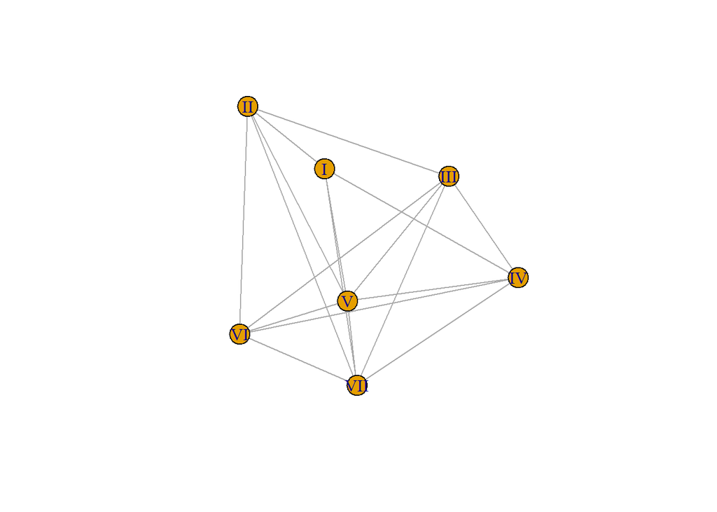

```r
library(igraph)
net<-graph_from_adjacency_matrix(uw,mode="undirected",weighted = T,diag = FALSE)
set.seed(42)
plot(net)
```

- Lastly, we identify the communities using the Louvain method:

```r
clp <- cluster_louvain(net)
membership(clp)
```

```
##   I  II III  IV   V  VI VII
##   1   1   2   2   3   3   3
```

- It shows that there are three communities here. I and II are in the first. III and IV are in the second. The others are in the third.
- Now that we have everything. All we need to do is to combine them and make them look nicer.

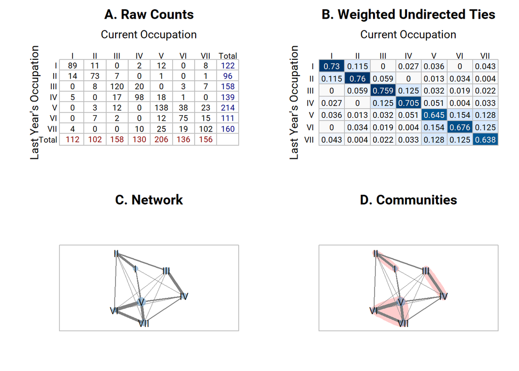

```r
###Figure Parameters
windowsFonts(A = windowsFont("Roboto"))
par(family="A",mar=c(4, 6, 6, 2) + 0.1)
lo<-matrix(c(1,1,1,2,2,2,
            3,3,3,4,4,4),ncol=6,byrow = T)
layout(lo)

###PANEL A
plot(0,col="transparent",xlim=c(0.2,(num+1)/1.04),ylim=c(0.2,(num+1)/1.04),xlab="",ylab="",
     xaxt="n",yaxt="n")
box(col="grey")
abline(h=seq(-1:num+1),col="grey")
abline(v=seq(-1:num+1),col="grey")
text(seq(0.5,num+0.5,1),rep(num+1.4,num),xpd=T, c(occlab,"Total"))
text(rep(-0.2,num),rev(seq(0.5,num+0.5,1)),xpd=T, c(occlab," Total"),adj=1)
mtext("Last Year's Occupation",side=2,line=2,cex=0.9)
mtext("Current Occupation",side=3,line=2,cex=0.9)
mtext("A. Raw Counts",side=3,line=4,font=2,cex=1.1)
text(rep(seq(0.5,num-0.5,1),num),rep(rev(seq(1.5,num+0.5,1)),each=num),c,cex=1)

text(rep(num+0.5,num),rev(seq(1.5,num+0.5,1)),psize,cex=1,col="navy")
text(seq(0.5,num-0.5,1),rep(0.5,num),csize, cex=1,col="darkred")

###Panel B
c<-round(as.vector(t(uw)),digits=3)
image(1:num,1:num,t(uw)[,num:1],xlab="",ylab="",axes=FALSE,col=hcl.colors(num^2,"blues 3",rev=T),
      xaxt="n",yaxt="n")
box(col="grey")
abline(h=seq(0.5,num+0.5,1),col="grey")
abline(v=seq(0.5,num+0.5,1),col="grey")
text(seq(1,num,1),rep(num+0.85,num),xpd=T, occlab)
text(rep(0.3,num),rev(seq(1,num,1)),xpd=T, occlab,adj=1)
mtext("Last Year's Occupation",side=2,line=2,cex=0.9)
mtext("Current Occupation",side=3,line=2,cex=0.9)
mtext("B. Weighted Undirected Ties",side=3,line=4,font=2,cex=1.1)
text(rep(seq(1,num,1),num),rep(rev(seq(1,num,1)),each=num),c,cex=1)
text(1:num,num:1,diag(round(uw,digits = 3)),col="white",cex=1)

###Panel C
V(net)$label <- c("I","II","III","IV","V","VI","VII")
V(net)$label.cex<-1.2
V(net)$label.color<-"grey10"
V(net)$frame.color<-"transparent"
V(net)$label.family<-"A"
V(net)$size <- psize/8
V(net)$color<-adjustcolor("steelblue",alpha.f=0.5)
E(net)$width <- E(net)$weight*30
E(net)$arrow.size <- 0.01
E(net)$color <-adjustcolor("grey50",alpha.f = 1)
set.seed(42)
l <- layout_with_fr (net, weights=E(net)$weight)
plot(net,layout=l)
mtext("C. Network",side=3,line=4,font=2,cex=1.1)
box(col="grey")

###Panel D
plot(clp, net,col=adjustcolor("steelblue",alpha.f=0.5),layout=l,edge.color = adjustcolor("grey50",alpha.f = 1)
     ,mark.col=adjustcolor(c("red"),alpha.f=0.2),mark.border="transparent")
mtext("D. Communities",side=3,line=4,font=2,cex=1.1)
box(col="grey")
```

**End of the script**